# Weightlifting Exercise Project

David Himrich

Saturday, February 21, 2015

This project uses data gathered by the authors of this paper:

> Velloso, E.; Bulling, A.; Gellersen, H.; Ugulino, W.; Fuks, H. Qualitative Activity Recognition of Weight Lifting Exercises. Proceedings of 4th International Conference in Cooperation with SIGCHI (Augmented Human ’13) . Stuttgart, Germany: ACM SIGCHI, 2013.

Read more: http://groupware.les.inf.puc-rio.br/har#ixzz3SOZmsUS2

# Data Preparation

I downloaded the data sets from the sources specified by the Coursera instructors.

```r
train.url <- "https://d396qusza40orc.cloudfront.net/predmachlearn/pml-training.csv"

# download.file(train.url, destfile="wle_training.csv")

test.url <- "https://d396qusza40orc.cloudfront.net/predmachlearn/pml-testing.csv"

# download.file(test.url, destfile="wle_testing.csv")
```

```r
library(caret)
training.df <- read.csv("wle_training.csv")

## Remove the calculated feature rows, the ones with "new_window" variable
## equal to "yes"
train.pre.df <- training.df[training.df$new_window %in% "no", ]

## That produces a data frame with 19216 rows

train.pre.df <- droplevels(train.pre.df)

## The nearZeroVar function identifies correctly a number of calculated feature columns
## that are missing but not coded NA
nearZeroVar(train.pre.df, saveMetrics = TRUE)
```

```
##                          freqRatio percentUnique zeroVar   nzv
## X                         1.000000  1.000000e+02   FALSE FALSE
## user_name                 1.102460  3.122398e-02   FALSE FALSE
## raw_timestamp_part_1      1.000000  4.355745e+00   FALSE FALSE
## raw_timestamp_part_2      1.000000  8.568901e+01   FALSE FALSE
## cvtd_timestamp            1.002041  1.040799e-01   FALSE FALSE
## new_window                0.000000  5.203997e-03    TRUE  TRUE
## num_window                1.000000  4.459825e+00   FALSE FALSE
## roll_belt                 1.086168  6.838052e+00   FALSE FALSE
## pitch_belt                1.036649  9.538926e+00   FALSE FALSE
## yaw_belt                  1.047244  1.010616e+01   FALSE FALSE
## total_accel_belt          1.069434  1.509159e-01   FALSE FALSE
## kurtosis_roll_belt        0.000000  5.203997e-03    TRUE  TRUE
## kurtosis_picth_belt       0.000000  5.203997e-03    TRUE  TRUE
## kurtosis_yaw_belt         0.000000  5.203997e-03    TRUE  TRUE
## skewness_roll_belt        0.000000  5.203997e-03    TRUE  TRUE
## skewness_roll_belt.1      0.000000  5.203997e-03    TRUE  TRUE
## skewness_yaw_belt         0.000000  5.203997e-03    TRUE  TRUE
## max_roll_belt             0.000000  0.000000e+00    TRUE  TRUE
## max_picth_belt            0.000000  0.000000e+00    TRUE  TRUE
## max_yaw_belt              0.000000  5.203997e-03    TRUE  TRUE
## min_roll_belt             0.000000  0.000000e+00    TRUE  TRUE
## min_pitch_belt            0.000000  0.000000e+00    TRUE  TRUE
## min_yaw_belt              0.000000  5.203997e-03    TRUE  TRUE
## amplitude_roll_belt       0.000000  0.000000e+00    TRUE  TRUE
## amplitude_pitch_belt      0.000000  0.000000e+00    TRUE  TRUE
## amplitude_yaw_belt        0.000000  5.203997e-03    TRUE  TRUE
## var_total_accel_belt      0.000000  0.000000e+00    TRUE  TRUE
## avg_roll_belt             0.000000  0.000000e+00    TRUE  TRUE
## stddev_roll_belt          0.000000  0.000000e+00    TRUE  TRUE
## var_roll_belt             0.000000  0.000000e+00    TRUE  TRUE
## avg_pitch_belt            0.000000  0.000000e+00    TRUE  TRUE
## stddev_pitch_belt         0.000000  0.000000e+00    TRUE  TRUE
## var_pitch_belt            0.000000  0.000000e+00    TRUE  TRUE
## avg_yaw_belt              0.000000  0.000000e+00    TRUE  TRUE
## stddev_yaw_belt           0.000000  0.000000e+00    TRUE  TRUE
## var_yaw_belt              0.000000  0.000000e+00    TRUE  TRUE
## gyros_belt_x              1.050784  7.233555e-01   FALSE FALSE
## gyros_belt_y              1.148947  3.590758e-01   FALSE FALSE
## gyros_belt_z              1.071098  8.794754e-01   FALSE FALSE
```

[output cut: 106 more lines]

```
## stddev_pitch_forearm      0.000000  0.000000e+00    TRUE  TRUE
## var_pitch_forearm         0.000000  0.000000e+00    TRUE  TRUE
## avg_yaw_forearm           0.000000  0.000000e+00    TRUE  TRUE
## stddev_yaw_forearm        0.000000  0.000000e+00    TRUE  TRUE
## var_yaw_forearm           0.000000  0.000000e+00    TRUE  TRUE
## gyros_forearm_x           1.050193  1.545587e+00   FALSE FALSE
## gyros_forearm_y           1.043011  3.840550e+00   FALSE FALSE
## gyros_forearm_z           1.112051  1.582015e+00   FALSE FALSE
## accel_forearm_x           1.142857  4.131973e+00   FALSE FALSE
## accel_forearm_y           1.050000  5.209201e+00   FALSE FALSE
## accel_forearm_z           1.019231  3.013114e+00   FALSE FALSE
## magnet_forearm_x          1.012658  7.925687e+00   FALSE FALSE
## magnet_forearm_y          1.256410  9.726270e+00   FALSE FALSE
## magnet_forearm_z          1.017544  8.758326e+00   FALSE FALSE
## classe                    1.471490  2.601998e-02   FALSE FALSE
```

```r
## We can use the column positions of nzv== TRUE to remove the un-needed columns:
nzv <- nearZeroVar(train.pre.df)
train.pre.df <- train.pre.df[,-nzv]

## Remove the original training data
rm(training.df)
```

These first pre-processing steps produced a data frame with 6 columns of identifiers, 52 columns of censor data, and the “classe” outcome variable. The `featurePlot` function from the caret package revealed a few extreme outlier values among the sensor data. I used various plots to confirm that these values were not consistent with the time series in which they are found. They appear to be transcription errors of some kind. I replaced them with NA values and then used the ‘preProcess’ function on all the columns of sensor data impute values to replace the outliers. That process also centered and scaled the sensor data.

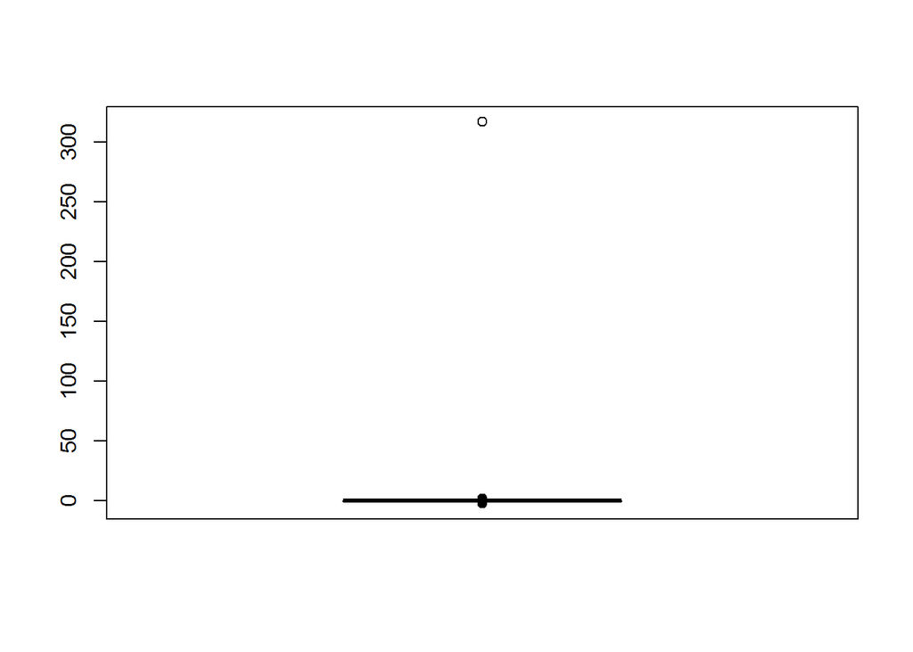

```r
## Example with one variable of outlier identification and removal
boxplot(train.pre.df$gyros_dumbbell_z)
```

```r
which(train.pre.df$gyros_dumbbell_z > 250)
```

```
## [1] 5270
```

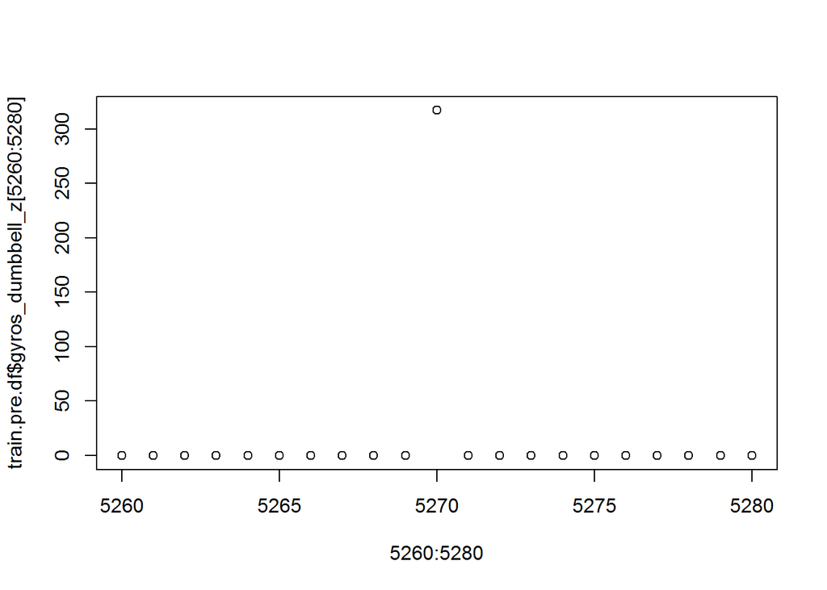

```r
plot(5260:5280, train.pre.df$gyros_dumbbell_z[5260:5280])
```

```r
train.pre.df$gyros_dumbbell_z[5270]
```

```
## [1] 317
```

```r
train.pre.df$gyros_dumbbell_z[5270] <- NA

## I proceeded in similar fashion to replace other outliers
which(train.pre.df$gyros_dumbbell_x < -150)
```

```
## [1] 5270
```

```r
train.pre.df$gyros_dumbbell_x[5270]
```

```
## [1] -204
```

```r
train.pre.df$gyros_dumbbell_x[5270] <- NA

which(train.pre.df$gyros_dumbbell_y > 50)
```

```
## [1] 5270
```

```r
train.pre.df$gyros_dumbbell_y[5270]
```

```
## [1] 52
```

```r
train.pre.df$gyros_dumbbell_y[5270] <- NA

which(train.pre.df$magnet_dumbbell_y < -3000)
```

```
## [1] 9088
```

```r
train.pre.df$magnet_dumbbell_y[9088]
```

```
## [1] -3600
```

```r
train.pre.df$magnet_dumbbell_y[9088] <- NA

which(train.pre.df$gyros_forearm_x < -10)
```

```
## [1] 5270
```

```r
train.pre.df$gyros_forearm_x[5270]
```

```
## [1] -22
```

```r
train.pre.df$gyros_forearm_x[5270] <- NA

which(train.pre.df$gyros_forearm_z > 200)
```

```
## [1] 5270
```

```r
train.pre.df$gyros_forearm_z[5270]
```

```
## [1] 231
```

```r
train.pre.df$gyros_forearm_z[5270] <- NA

which(train.pre.df$gyros_forearm_y > 200)
```

```
## [1] 5270
```

```r
train.pre.df$gyros_forearm_y[5270]
```

```
## [1] 311
```

```r
train.pre.df$gyros_forearm_y[5270] <- NA

## Apply the preProcess function to all the sensor columns to center, scale
## and impute values to the just-created NA values
sensor_cols <- colnames(train.pre.df)[7:58]
preObj <- preProcess(train.pre.df[,sensor_cols],method="knnImpute")
train.pre.df[,sensor_cols] <- predict(preObj, train.pre.df[,sensor_cols])
```

# Model Training

Having removed the apparent transcription errors, I split the pre-processed training data into a training set and a validation set, fit a random forests model to the training data, and evaluated the results.

```r
## Make training and validation data sets
inTrain <- createDataPartition(y=train.pre.df$classe, p=0.75, list=FALSE)

train.pre <- train.pre.df[inTrain, ]
valid.pre <- train.pre.df[-inTrain, ]

## Try a random forest using only the sensor data, set the measurement method "oob"
set.seed(1927)
WLE.rf <- train(x=train.pre[,sensor_cols],y=train.pre[,"classe"] ,
                method="rf", trControl=trainControl(method="oob"))
## Examine the model
WLE.rf
```

```
## Random Forest
##
## 14414 samples
##    52 predictor
##     5 classes: 'A', 'B', 'C', 'D', 'E'
##
## No pre-processing
## Resampling results across tuning parameters:
##
##   mtry  Accuracy   Kappa
##    2    0.9934092  0.9916616
##   27    0.9928542  0.9909598
##   52    0.9852921  0.9813914
##
## Accuracy was used to select the optimal model using  the largest value.
## The final value used for the model was mtry = 2.
```

```r
WLE.rf$results
```

```
##    Accuracy     Kappa mtry
## 1 0.9934092 0.9916616    2
## 2 0.9928542 0.9909598   27
## 3 0.9852921 0.9813914   52
```

```r
WLE.rf$finalModel
```

```
##
## Call:
##  randomForest(x = x, y = y, mtry = param$mtry)
##                Type of random forest: classification
##                      Number of trees: 500
## No. of variables tried at each split: 2
##
##         OOB estimate of  error rate: 0.65%
## Confusion matrix:
##      A    B    C    D    E  class.error
## A 4102    2    0    0    0 0.0004873294
## B   16 2768    5    0    0 0.0075295805
## C    0   22 2490    2    0 0.0095465394
## D    0    0   40 2319    2 0.0177890724
## E    0    0    1    4 2641 0.0018896447
```

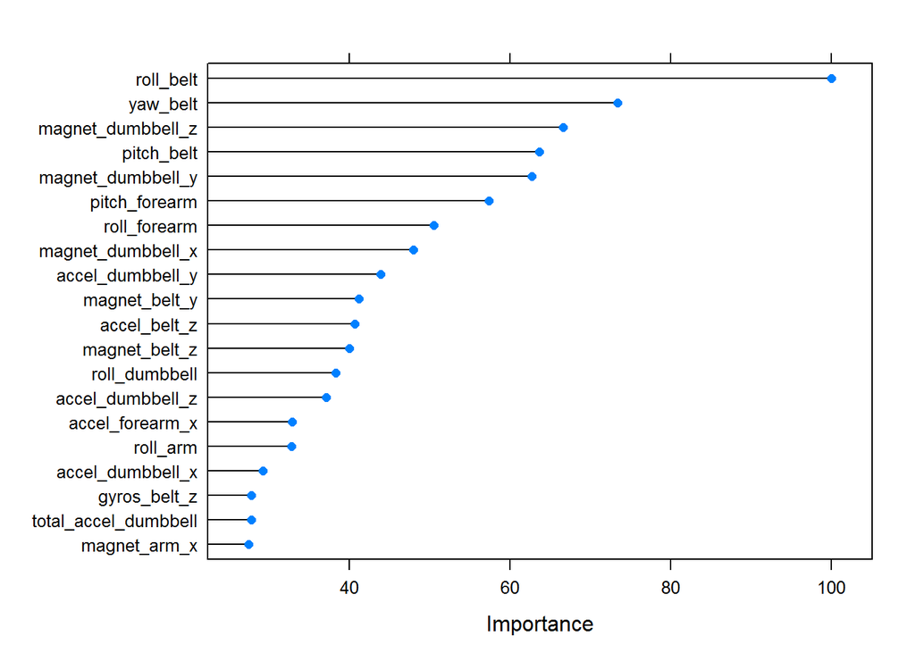

```r
## Plot the 20 variables with the highest importance in the final model
plot(varImp(WLE.rf), top=20)
```

This model appears to have a reasonably high accuracy rate (99.4%), especially considering that these sensor data are actually time series rather than independent observations. I would have preferred to pre-process the sensor data as time series, but the organization of the data is such that I was not confident that I could correctly identify the time series and pre-process them correctly.

# Model Validation

I proceeded by using this model to predict on the validation set I held out from the original training data. This may not have been strictly necessary, as the random forest method as applied by the train function from the caret package does some model tuning and cross-validation by default.

```r
# Predict on the validation set (internal partition) with the final model
pred.rf <- predict(WLE.rf$finalModel, valid.pre)
confusionMatrix(pred.rf,valid.pre$classe)
```

```
## Confusion Matrix and Statistics
##
##           Reference
## Prediction    A    B    C    D    E
##          A 1367    3    1    0    0
##          B    0  925    4    0    0
##          C    0    1  833    8    0
##          D    0    0    0  778    1
##          E    0    0    0    0  881
##
## Overall Statistics
##
##                Accuracy : 0.9963
##                  95% CI : (0.9941, 0.9978)
##     No Information Rate : 0.2847
##     P-Value [Acc > NIR] : < 2.2e-16
##
##                   Kappa : 0.9953
##  Mcnemar's Test P-Value : NA
##
## Statistics by Class:
##
##                      Class: A Class: B Class: C Class: D Class: E
## Sensitivity            1.0000   0.9957   0.9940   0.9898   0.9989
## Specificity            0.9988   0.9990   0.9977   0.9998   1.0000
## Pos Pred Value         0.9971   0.9957   0.9893   0.9987   1.0000
## Neg Pred Value         1.0000   0.9990   0.9987   0.9980   0.9997
## Prevalence             0.2847   0.1935   0.1745   0.1637   0.1837
## Detection Rate         0.2847   0.1926   0.1735   0.1620   0.1835
## Detection Prevalence   0.2855   0.1935   0.1753   0.1622   0.1835
## Balanced Accuracy      0.9994   0.9973   0.9959   0.9948   0.9994
```

# Predictions on Test Data

The test data are only 20 observation from streams of sensor data. This initial random forest model appears to be accurate enough to attempt predictions for those test observations and submit them for credit.

```r
testing.df <- read.csv("wle_testing.csv", na.strings=c(""," ","NA"))
## Process as with the test set
## Keep only new_window = no
test.pre.df <- testing.df[testing.df$new_window %in% "no", ]

## look for near-zero variance columns
nearZeroVar(test.pre.df, saveMetrics = TRUE)
```

```
##                          freqRatio percentUnique zeroVar   nzv
## X                         1.000000           100   FALSE FALSE
## user_name                 2.000000            30   FALSE FALSE
## raw_timestamp_part_1      1.000000           100   FALSE FALSE
## raw_timestamp_part_2      1.000000           100   FALSE FALSE
## cvtd_timestamp            1.333333            55   FALSE FALSE
## new_window                0.000000             5    TRUE  TRUE
## num_window                1.000000           100   FALSE FALSE
## roll_belt                 1.000000            90   FALSE FALSE
## pitch_belt                1.000000           100   FALSE FALSE
## yaw_belt                  1.000000            90   FALSE FALSE
## total_accel_belt          1.200000            45   FALSE FALSE
## kurtosis_roll_belt        0.000000             0    TRUE  TRUE
## kurtosis_picth_belt       0.000000             0    TRUE  TRUE
## kurtosis_yaw_belt         0.000000             0    TRUE  TRUE
## skewness_roll_belt        0.000000             0    TRUE  TRUE
## skewness_roll_belt.1      0.000000             0    TRUE  TRUE
## skewness_yaw_belt         0.000000             0    TRUE  TRUE
## max_roll_belt             0.000000             0    TRUE  TRUE
## max_picth_belt            0.000000             0    TRUE  TRUE
## max_yaw_belt              0.000000             0    TRUE  TRUE
## min_roll_belt             0.000000             0    TRUE  TRUE
## min_pitch_belt            0.000000             0    TRUE  TRUE
## min_yaw_belt              0.000000             0    TRUE  TRUE
## amplitude_roll_belt       0.000000             0    TRUE  TRUE
## amplitude_pitch_belt      0.000000             0    TRUE  TRUE
## amplitude_yaw_belt        0.000000             0    TRUE  TRUE
## var_total_accel_belt      0.000000             0    TRUE  TRUE
## avg_roll_belt             0.000000             0    TRUE  TRUE
## stddev_roll_belt          0.000000             0    TRUE  TRUE
## var_roll_belt             0.000000             0    TRUE  TRUE
## avg_pitch_belt            0.000000             0    TRUE  TRUE
## stddev_pitch_belt         0.000000             0    TRUE  TRUE
## var_pitch_belt            0.000000             0    TRUE  TRUE
## avg_yaw_belt              0.000000             0    TRUE  TRUE
## stddev_yaw_belt           0.000000             0    TRUE  TRUE
## var_yaw_belt              0.000000             0    TRUE  TRUE
## gyros_belt_x              1.500000            70   FALSE FALSE
## gyros_belt_y              2.250000            30   FALSE FALSE
## gyros_belt_z              2.500000            65   FALSE FALSE
```

[output cut: 106 more lines]

```
## stddev_pitch_forearm      0.000000             0    TRUE  TRUE
## var_pitch_forearm         0.000000             0    TRUE  TRUE
## avg_yaw_forearm           0.000000             0    TRUE  TRUE
## stddev_yaw_forearm        0.000000             0    TRUE  TRUE
## var_yaw_forearm           0.000000             0    TRUE  TRUE
## gyros_forearm_x           1.000000            90   FALSE FALSE
## gyros_forearm_y           1.000000           100   FALSE FALSE
## gyros_forearm_z           1.000000           100   FALSE FALSE
## accel_forearm_x           1.000000           100   FALSE FALSE
## accel_forearm_y           1.000000           100   FALSE FALSE
## accel_forearm_z           1.000000           100   FALSE FALSE
## magnet_forearm_x          1.000000           100   FALSE FALSE
## magnet_forearm_y          1.000000           100   FALSE FALSE
## magnet_forearm_z          1.000000           100   FALSE FALSE
## problem_id                1.000000           100   FALSE FALSE
```

```r
## that appears to identify all the calculated feature columns again
## remove those nzv columns
nzv2 <- nearZeroVar(test.pre.df)
test.pre.df <- test.pre.df[,-nzv2]

test.pre.df <- droplevels(test.pre.df)

## now there are 59 columns like the training set, check the names
setdiff(colnames(train.pre.df), colnames(test.pre.df))
```

```
## [1] "classe"
```

```r
setdiff(colnames(test.pre.df), colnames(train.pre.df))
```

```
## [1] "problem_id"
```

```r
# remove the original testing.df, we don't need it
rm(testing.df)

## Check if you can use the sensor_cols vector
setdiff(sensor_cols, colnames(test.pre.df))
```

```
## character(0)
```

```r
setdiff(colnames(test.pre.df), sensor_cols)
```

```
## [1] "X"                    "user_name"            "raw_timestamp_part_1"
## [4] "raw_timestamp_part_2" "cvtd_timestamp"       "num_window"
## [7] "problem_id"
```

```r
## That showed only the identifier columns as not in the sensor_cols vector
## Apply the preprocessing object from the training set to the sensor columns to center and scale
## would also impute NA values, which I think are not present
test.pre.df[,sensor_cols] <- predict(preObj, test.pre.df[,sensor_cols])

# Predict on the test set with the final model
predicted.test.rf <- predict(WLE.rf, test.pre.df)

# change this from a list to a character vector
predicted.test.rf <- as.character(predicted.test.rf)
class(predicted.test.rf)
```

```
## [1] "character"
```

I submitted these final predictions on the test data to the Coursera web site and found that all 20 were correct.

# Conclusions

I found it very interesting that it was possible to ignore the time-series nature of the sensor data and still make accurate predictions of the exercise classification, even on single observations as in the final test set. Perhaps pre-processing the data as time-series would be too computationally intense for application in real-time exercise monitoring. On the other hand, the Global Positioning System is also computationally demanding, but very compact receivers that accomplish those calculations have been implemented with specialized chipsets. Presumably something similar could be created to monitor exercise technique.